# Lecture 7 Seminar slides with answers

Regression

Press F for fullscreen

# Understanding contrasts a bit more

- For this seminar, we will use an invented data set that will let you experience a bit more about how contrasts work
- Please download the following data set from Brightspace and open it in jamovi/SPSS: fluffy.csv
  - For SPSS, you may have to use the CSV import wizard (see [here](https://libguides.library.kent.edu/SPSS/ImportData) for detailed instructions)
  - jamovi will open the file immediately without issues.
- These (fictitious) data are from an experiment in which participant rate the positivity of emotions triggered by looking at photos of different dogs and cats (on a scale from 0 - 100, where 0 is most negative and 100 is most positive).
- An unrelated group of participants rated the same photos in terms of how fluffy they thought the animal was (also on a scale from 0 to 100, where 0 is sandpaper and 100 is extra-soft plush fabric).
- Also, the file notes whether the photo showed a cat or a dog.

# Your task

- First, perform a regression analysis where you predict positive feelings only by fluffiness. Note down the results, and write one sentence to summarise what they suggest.
- Then, perform a regression analysis where, in addition to fluffiness, you also add animal type (cat vs. dog) as a discrete predictor. How is this model different from the first one? How can you explain the difference?

# Set up the tests

- Start by fitting a regression model on `positive_feelings` with just `fluffiness`
  - You can do that in the `Linear Regression` module in jamovi.
    - In SPSS, use `General Linear Model` → `Univariate...` so it is easier to add the factor later.

# Results: Simple regression

- Note the slope for `fluffiness`.

|  | positive_feelings |  |  |  |
| --- | --- | --- | --- | --- |
| Predictors | Estimates | CI | Statistic | p |
| (Intercept) | 70.80 | 64.07 – 77.54 | 20.87 | **<0.001** |
| fluffiness | -0.46 | -0.59 – -0.33 | -7.01 | **<0.001** |
| Observations | 100 |  |  |  |
| R<sup>2</sup> / R<sup>2</sup> adjusted | 0.334 / 0.327 |  |  |  |

- In words: We fitted a linear model (estimated using OLS) to predict positive_feelings with fluffiness (formula: positive_feelings ~ fluffiness). The model explains a statistically significant and substantial proportion of variance (R2 = 0.33, F(1, 98) = 49.17, p < .001, adj. R2 = 0.33). The model’s intercept, corresponding to fluffiness = 0, is at 70.80 (95% CI [64.07, 77.54], t(98) = 20.87, p < .001). Within this model:
- The effect of fluffiness is statistically significant and negative (beta = -0.46, 95% CI [-0.59, -0.33], t(98) = -7.01, p < .001; Std. beta = -0.58, 95% CI [-0.74, -0.41])

Standardized parameters were obtained by fitting the model on a standardized version of the dataset. 95% Confidence Intervals (CIs) and p-values were computed using the Wald approximation.

# Now add the contrast for animal

- In SPSS/jamovi: add `animal` to `Factors`
- What happens to the slope for `fluffiness`?

# Results: adding the contrast

|  | positive_feelings |  |  |  |
| --- | --- | --- | --- | --- |
| Predictors | Estimates | CI | Statistic | p |
| (Intercept) | -42.83 | -56.25 – -29.41 | -6.33 | **<0.001** |
| fluffiness | 1.13 | 0.94 – 1.32 | 11.59 | **<0.001** |
| animal [dog] | 84.02 | 74.41 – 93.63 | 17.35 | **<0.001** |
| Observations | 100 |  |  |  |
| R<sup>2</sup> / R<sup>2</sup> adjusted | 0.838 / 0.834 |  |  |  |

# Results: adding the contrast (in words)

- In words: We fitted a linear model (estimated using OLS) to predict positive_feelings with fluffiness and animal (formula: positive_feelings ~ fluffiness + animal). The model explains a statistically significant and substantial proportion of variance (R2 = 0.84, F(2, 97) = 250.41, p < .001, adj. R2 = 0.83). The model’s intercept, corresponding to fluffiness = 0 and animal = cat, is at -42.83 (95% CI [-56.25, -29.41], t(97) = -6.33, p < .001). Within this model:
- The effect of fluffiness is statistically significant and positive (beta = 1.13, 95% CI [0.94, 1.32], t(97) = 11.59, p < .001; Std. beta = 1.41, 95% CI [1.17, 1.65])
- The effect of animal [dog] is statistically significant and positive (beta = 84.02, 95% CI [74.41, 93.63], t(97) = 17.35, p < .001; Std. beta = 4.20, 95% CI [3.72, 4.68])

Standardized parameters were obtained by fitting the model on a standardized version of the dataset. 95% Confidence Intervals (CIs) and p-values were computed using the Wald approximation. - (note that this is a standard reporting template that was automatically generated, so you don’t have to follow it exactly)

# Question

- Why was the slope for `fluffiness` negative when only `fluffiness` was in the model, but positive when we have both `fluffiness` and `animal` in the model?
- How is this related to the idea of “statistically controlling” for a variable?
- Hint: plotting might help – think of Anscombe’s Quartet!

# Answer

- Consider the plot of the analysis of fluffiness alone:

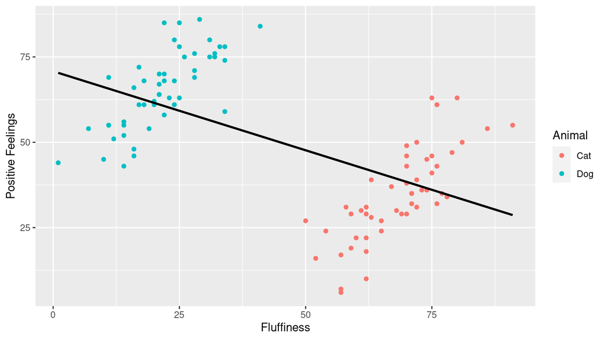

# Answer (2)

- And now the plot for the analysis including `animal`:

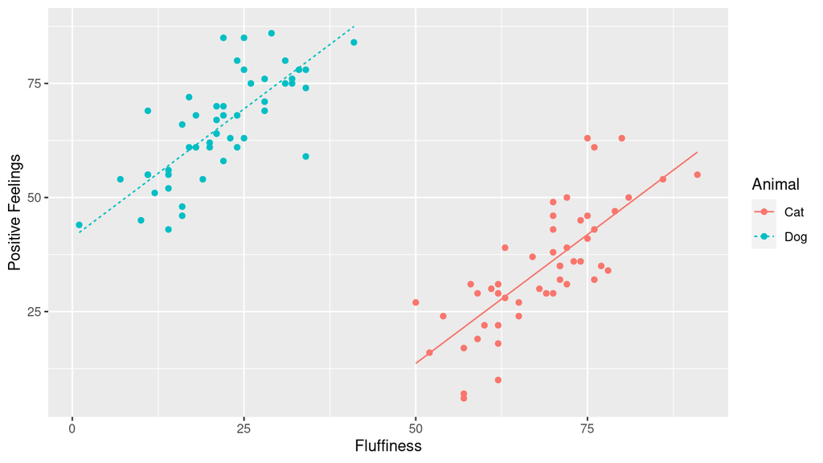

# Answer (3)

- As you can see, the line fitted when `animal` is not included is technically the best possible fit if you don’t know that there are two groups, but in practice it ignores the trend we care about
- When we take `animal` into account, we can fit the line **within** the groups instead of **between**
- In this way, we can say that we have controlled for the effect of `animal` statistically – we have removed the confound by including the confounding variable in the model
- Of course, it does not always work this nicely in reality!
- For example, the slope does not have to be the same for cats and dogs.

# Final activity (if there is time)

- Use a contrast of -1 and 1 for `animal` instead of 0 and 1.
- What changes?
- Write the regression equation and plug in the dummy values.
- Why is the coefficient in the -1 and 1 model exactly half of the coefficient in the 0 and 1 model?

# Answer

|  | positive_feelings |  |  |  |
| --- | --- | --- | --- | --- |
| Predictors | Estimates | CI | Statistic | p |
| (Intercept) | -0.82 | -9.67 – 8.02 | -0.18 | 0.854 |
| fluffiness | 1.13 | 0.94 – 1.32 | 11.59 | **<0.001** |
| animal [1] | -42.01 | -46.81 – -37.20 | -17.35 | **<0.001** |
| Observations | 100 |  |  |  |
| R<sup>2</sup> / R<sup>2</sup> adjusted | 0.838 / 0.834 |  |  |  |

- The value of the coefficient always tells us how much the y-value changes when the x-value changes by 1
- When we use the 0 and 1 contrasts, that means the means for cat and dog are exactly 1 unit on the x-axis apart
  - That means 1 unit on the x-axis corresponds to 84 units on the y-axis
- When we use the -1 and 1 contrasts, that means the means for cat and dog are exactly 2 unit on the x-axis apart
  - That means 1 unit on the x-axis corresponds to 42 units on the y-axis